# Communication Systems, January 2024

## Roja Atashkar 400100543

```python
import matplotlib.pyplot as plt
import numpy as np
import scipy
```

## Implementation of blocks individually

### 2.1

To simulate a real-time communication system, it's important to consider the concept of interleaving. Interleaving is a process that spreads out consecutive bits in a sequence to mitigate the effects of burst errors that may occur in the transmission channel. By interleaving the bits, errors affecting consecutive bits are spread apart, making it easier to recover the original information at the receiver.

```python
def Divide(sequence):
    length = len(sequence)
    if length % 2 != 0:
        raise ValueError("Input sequence length must be even.")

    half_length = length // 2
    sequence1 = []
    sequence2 = []
    for i in range(half_length):
        sequence1.append(sequence[2*i])
        sequence2.append(sequence[2*i + 1])

    return sequence1, sequence2
```

```python
def Combine(sequence1, sequence2):
    if len(sequence1) != len(sequence2):
        raise ValueError("Input sequences must have the same length.")

    combined_sequence = []
    for i in range(len(sequence1)):
        combined_sequence.append(sequence1[i])
        combined_sequence.append(sequence2[i])

    return combined_sequence
```

### 2.2

```python
def PulseShaping(sequence, zero_pulse, one_pulse):
    if len(zero_pulse) != len(one_pulse):
        raise ValueError("Length of zero_pulse and one_pulse must be equal.")

    pulse_length = len(zero_pulse)
    waveform = np.zeros(len(sequence) * pulse_length)

    for i, bit in enumerate(sequence):
        if bit == 0:
            waveform[i * pulse_length : (i + 1) * pulse_length] += zero_pulse
        elif bit == 1:
            waveform[i * pulse_length : (i + 1) * pulse_length] += one_pulse
        else:
            raise ValueError("Sequence must contain only zeros and ones.")

    return waveform
```

### 2.3

AM combines a baseband signal with a carrier signal to generate the modulated signal.

```python
def AnalogMod(baseband_signal_1, baseband_signal_2, sampling_frequency, carrier_frequency):
    time = np.arange(len(baseband_signal_1)) / sampling_frequency

    carrier_signal_1 = np.cos(2 * np.pi * carrier_frequency * time)
    carrier_signal_2 = np.sin(2 * np.pi * carrier_frequency * time)
    modulated_signal = baseband_signal_1 * carrier_signal_1 + baseband_signal_2*carrier_signal_2

    return modulated_signal
```

### 2.4

```python
def Channel(signal, sampling_frequency, center_frequency, bandwidth):
    nyquist_frequency = sampling_frequency / 2.0
    low_cutoff = center_frequency - bandwidth / 2.0
    high_cutoff = center_frequency + bandwidth / 2.0

    # Calculate filter coefficients
    b, a = scipy.signal.butter(4, [low_cutoff / nyquist_frequency, high_cutoff / nyquist_frequency], btype='band')

    # Apply the filter to the signal
    filtered_signal = scipy.signal.lfilter(b, a, signal)

    return filtered_signal
```

### 2.5

```python
def AnalogDemod(received_signal, sampling_frequency, signal_bandwidth, carrier_frequency):
    time = np.arange(len(received_signal)) / sampling_frequency


    carrier_signal_1 = np.cos(2 * np.pi * carrier_frequency * time)
    carrier_signal_2 = np.sin(2 * np.pi * carrier_frequency * time)

    demodulated_signal1 = received_signal * carrier_signal_1
    demodulated_signal2 = received_signal * carrier_signal_2

    # Design a low-pass filter
    nyquist_frequency = sampling_frequency / 2.0
    cutoff_frequency = signal_bandwidth / 2.0
    filter_order = 4
    b, a = scipy.signal.butter(filter_order, cutoff_frequency / nyquist_frequency, btype='low')

    # Apply the low-pass filter to the demodulated signals
    demodulated_signal1 = scipy.signal.lfilter(b, a, demodulated_signal1)
    demodulated_signal2 = scipy.signal.lfilter(b, a, demodulated_signal2)

    return demodulated_signal1, demodulated_signal2
```

### 2.6

```python
def MatchedFilter(demodulated_signal, pulse_shape_zero, pulse_shape_one):
    # Matched filter for pulse shape corresponding to zero
    matched_filter_output_zero = scipy.signal.correlate(demodulated_signal, pulse_shape_zero, mode='same')

    # Matched filter for pulse shape corresponding to one
    matched_filter_output_one = scipy.signal.correlate(demodulated_signal, pulse_shape_one, mode='same')

    # Estimate bit values
    estimated_sequence = np.where(matched_filter_output_one > matched_filter_output_zero, 1, 0)

    return  matched_filter_output_one, matched_filter_output_zero, estimated_sequence
```

```python
def sample_and_quantize(pulse, estimates_sequence):
    l_pulse = len(pulse)
    l = int(len(estimates_sequence)/l_pulse)
    estimated_bits = np.zeros(l)
    step = int(l_pulse/2)
    for i in range(l):
        if estimates_sequence[step + i*l_pulse] > 0:
            estimated_bits[i] = 1
    return estimated_bits
```

## Transmission of a random sequence of zeros and ones

```python
sampling_frequency = 1e6
carrier_frequency = 10e3
center_frequency = 10e3
pulse_width = 10e-3
channel_bandwidth = 1e3
```

### 3.1.1

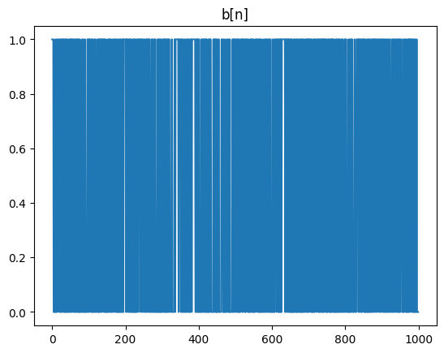

```python
import numpy as np
length = 1000
sequence = np.random.randint(2, size=length)
plt.plot(sequence)
plt.title("b[n]")
plt.show()
```

The bandwidth is determined by finding the index where the normalized spectrum drops below a certain threshold. In this case, the threshold is set to 0.05.

```python
# finding message signals bandwidth
def calculate_bandwidth(signal, sampling_frequency):
    spectrum = np.fft.fft(signal)
    magnitude_spectrum = np.abs(spectrum)
    half_length = len(signal) // 2
    normalized_spectrum = magnitude_spectrum[:half_length] / np.max(magnitude_spectrum)
    frequency_axis = np.fft.fftfreq(len(signal), 1 / sampling_frequency)[:half_length]

    # Find the index where the spectrum drops below a certain threshold
    threshold = 0.05  # Adjust this threshold as per your requirements
    bandwidth_index = np.where(normalized_spectrum < threshold)[0][0]

    bandwidth = 2 * frequency_axis[bandwidth_index]
    return bandwidth
```

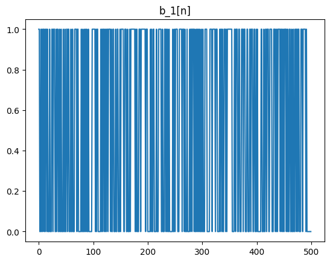

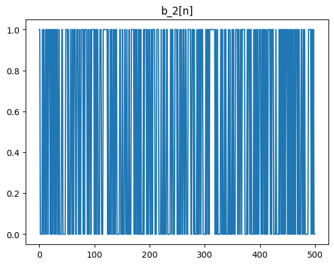

```python
# Transmitter
# Divide Block
b_1 , b_2 = Divide(sequence)
plt.plot(b_1)
plt.title("b_1[n]")
plt.show()
plt.plot(b_2)
plt.title("b_2[n]")
plt.show()
```

```python
bandwidth_1 = calculate_bandwidth(b_1, sampling_frequency)
print("Bandwidth_1:", bandwidth_1)
bandwidth_2 = calculate_bandwidth(b_2, sampling_frequency)
print("Bandwidth_2:", bandwidth_2)
```

```
Bandwidth_1: 4000.0
Bandwidth_2: 4000.0
```

```python
signal_bandwidth = max(bandwidth_1, bandwidth_2)
```

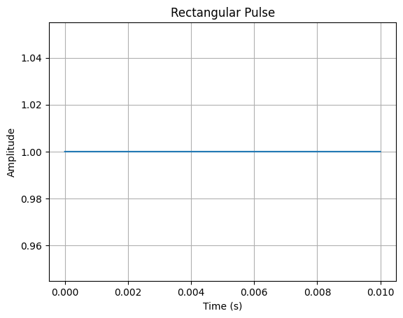

```python
# Pulse shaping block
def generate_rectangular_pulse(duration, amplitude, sampling_frequency):
    num_samples = int(duration * sampling_frequency)
    pulse = np.ones(num_samples) * amplitude
    return pulse
amp = 1
pulse = generate_rectangular_pulse(pulse_width, 1, sampling_frequency)

# Plotting the pulse
time = np.arange(0, pulse_width, 1 / sampling_frequency)
plt.plot(time, pulse)
plt.xlabel('Time (s)')
plt.ylabel('Amplitude')
plt.title('Rectangular Pulse')
plt.grid(True)
plt.show()
```

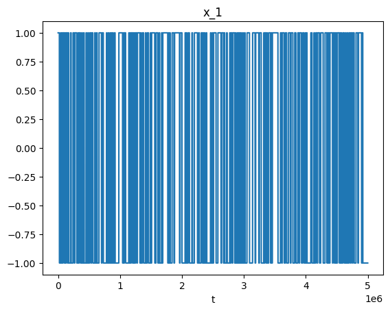

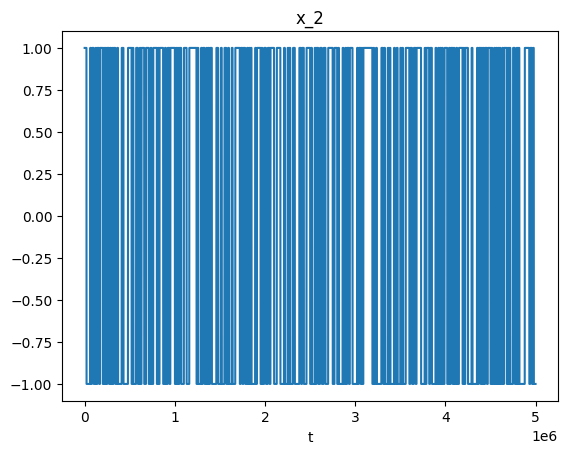

```python
x_1 = PulseShaping(b_1, -1*pulse, pulse)
x_2 = PulseShaping(b_2, -1*pulse, pulse)
plt.plot(x_1)
plt.title("x_1")
plt.xlabel("t")
plt.show()
plt.plot(x_2)
plt.title("x_2")
plt.xlabel("t")
plt.show()
```

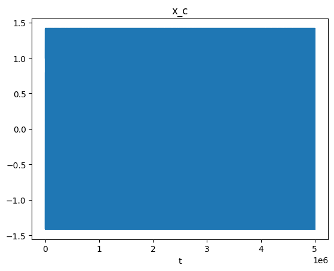

```python
# modulation Block
x_c = AnalogMod(x_1, x_2, sampling_frequency, carrier_frequency)
plt.plot(x_c)
plt.title("x_c")
plt.xlabel("t")
plt.show()
```

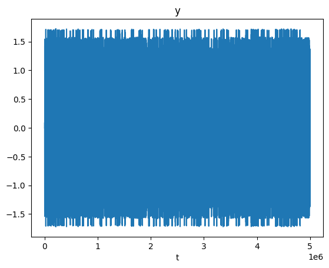

```python
# Receiver
# Channel Block
y = Channel(x_c, sampling_frequency,center_frequency,  channel_bandwidth)
plt.plot(y)
plt.title("y")
plt.xlabel("t")
plt.show()
```

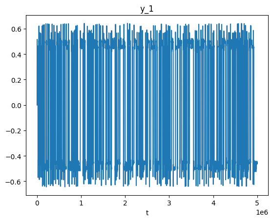

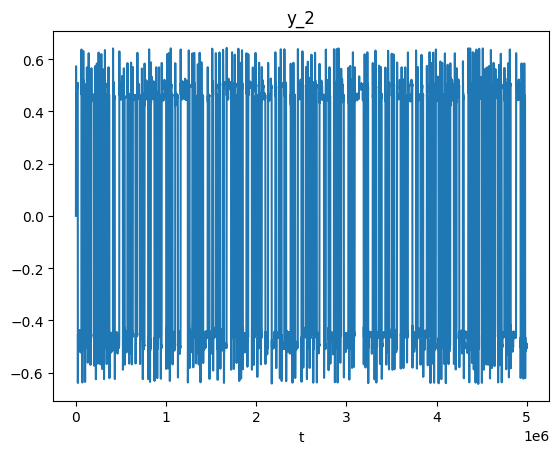

```python
# Demodulation block
y_1, y_2 = AnalogDemod(y, sampling_frequency, signal_bandwidth, carrier_frequency)
plt.plot(y_1)
plt.title("y_1")
plt.xlabel("t")
plt.show()
plt.plot(y_2)
plt.title("y_2")
plt.xlabel("t")
plt.show()
```

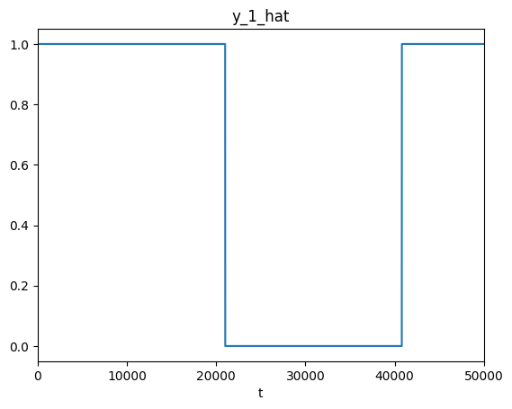

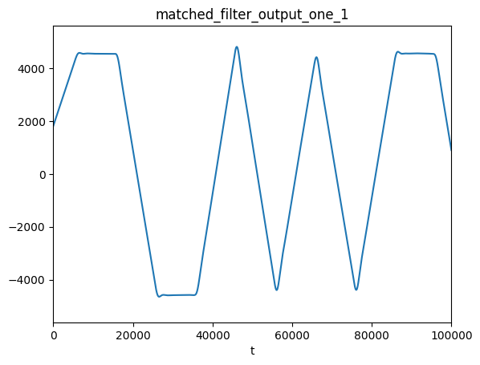

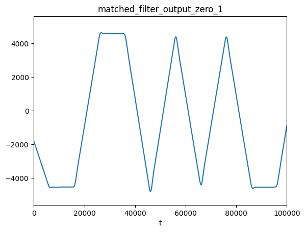

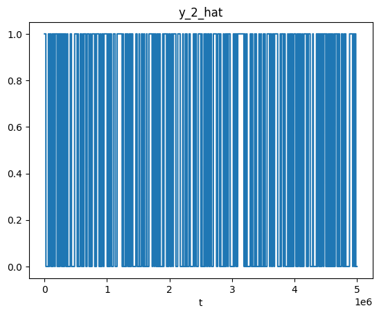

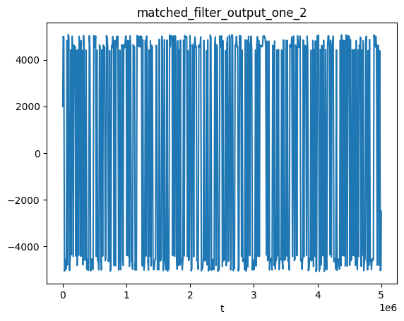

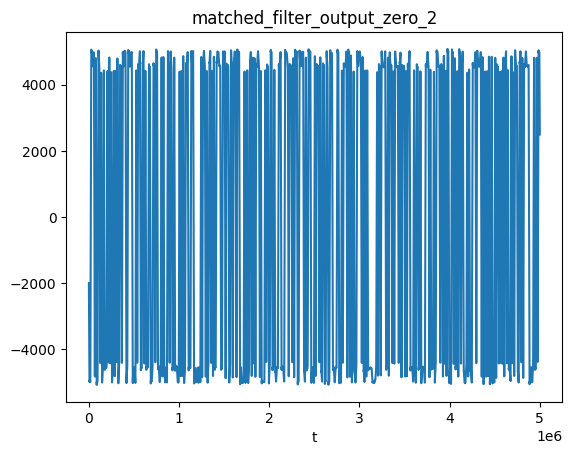

```python
# Matched filter and threshold
matched_filter_output_one_1, matched_filter_output_zero_1, y_1_hat = MatchedFilter(y_1, -1*pulse, pulse)
matched_filter_output_one_2, matched_filter_output_zero_2, y_2_hat = MatchedFilter(y_2, -1*pulse, pulse)
plt.plot(y_1_hat)
plt.title("y_1_hat")
plt.xlim(0, 5e4)
plt.xlabel("t")
plt.show()
plt.plot(matched_filter_output_one_1)
plt.title("matched_filter_output_one_1")
plt.xlim(0, 1e5)
plt.xlabel("t")
plt.show()
plt.plot(matched_filter_output_zero_1)
plt.title("matched_filter_output_zero_1")
plt.xlim(0, 1e5)
plt.xlabel("t")
plt.show()

plt.plot(y_2_hat)
plt.title("y_2_hat")
plt.xlabel("t")
plt.show()
plt.plot(matched_filter_output_one_2)
plt.title("matched_filter_output_one_2")
plt.xlabel("t")
plt.show()
plt.plot(matched_filter_output_zero_2)
plt.title("matched_filter_output_zero_2")
plt.xlabel("t")
plt.show()
```

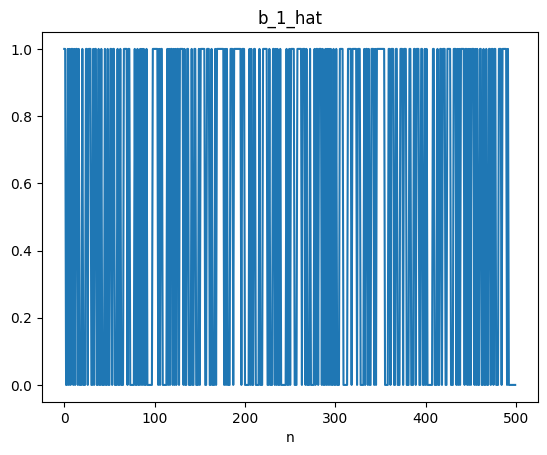

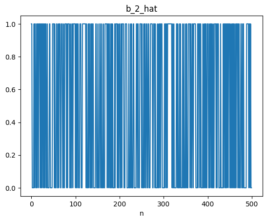

```python
estimated_bit_1 = sample_and_quantize(pulse, y_1_hat)
estimated_bit_2 = sample_and_quantize(pulse, y_2_hat)
plt.plot(estimated_bit_1)
plt.title("b_1_hat")
plt.xlabel("n")
plt.show()

plt.plot(estimated_bit_2)
plt.title("b_2_hat")
plt.xlabel("n")
plt.show()
```

```python
b = Combine(estimated_bit_1, estimated_bit_2)
print("bit error rate:" )
print(np.sum(b != sequence)/len(sequence))
```

```
bit error rate:
0.0
```

### 3.1.2

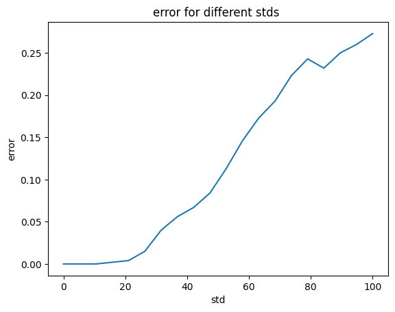

```python
mean = 0
num_samples = len(y)
stds = np.linspace(0, 100, 20)
errors = []
for std in stds:
    white_noise= np.random.normal(mean, std, size=num_samples)
    y_final = y + white_noise
    #plt.plot(y_final)
    #plt.show()
    y_1, y_2 = AnalogDemod(y_final, sampling_frequency, signal_bandwidth, carrier_frequency)
    matched_filter_output_one_1, matched_filter_output_zero_1, y_1_hat = MatchedFilter(y_1, -1*pulse, pulse)
    matched_filter_output_one_2, matched_filter_output_zero_2, y_2_hat = MatchedFilter(y_2, -1*pulse, pulse)
    estimated_bit_1 = sample_and_quantize(pulse, y_1_hat)
    estimated_bit_2 = sample_and_quantize(pulse, y_2_hat)
    b = Combine(estimated_bit_1, estimated_bit_2)
    errors.append(np.sum(b != sequence)/len(sequence))
plt.plot(stds, errors)
plt.title("error for different stds ")
plt.xlabel("std")
plt.ylabel("error")
```

### 3.1.3

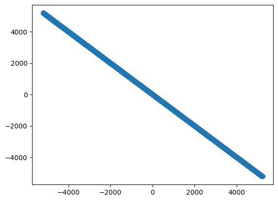

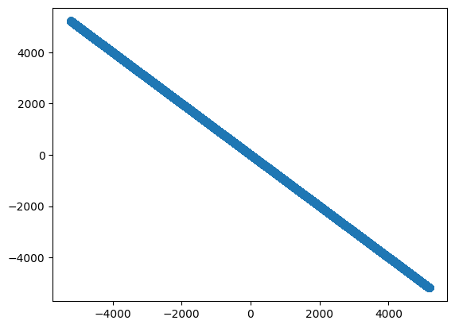

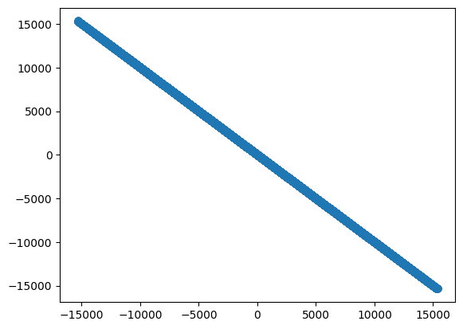

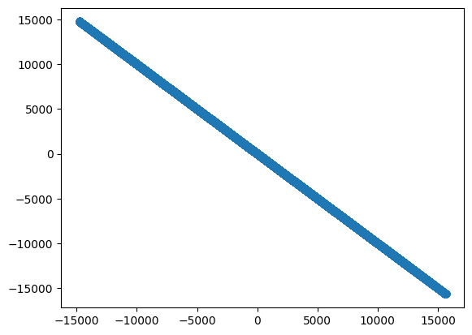

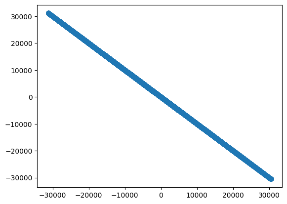

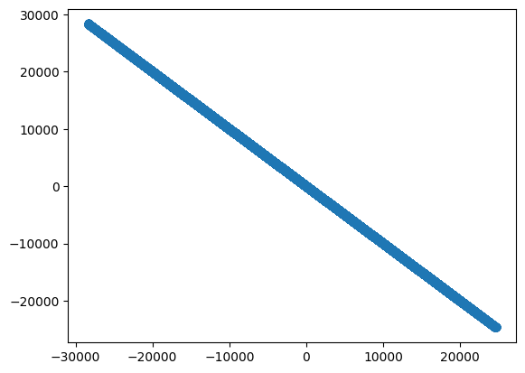

```python
mean = 0
stds = [1, 50, 100]
num_samples = len(y)
for std in stds:
    white_noise= np.random.normal(mean, std, size=num_samples)
    y_final = y + white_noise
    #plt.plot(y_final)
    #plt.show()
    y_1, y_2 = AnalogDemod(y_final, sampling_frequency, signal_bandwidth, carrier_frequency)
    matched_filter_output_one_1, matched_filter_output_zero_1, y_1_hat = MatchedFilter(y_1, -1*pulse, pulse)
    matched_filter_output_one_2, matched_filter_output_zero_2, y_2_hat = MatchedFilter(y_2, -1*pulse, pulse)
    estimated_bit_1 = sample_and_quantize(pulse, y_1_hat)
    estimated_bit_2 = sample_and_quantize(pulse, y_2_hat)
    plt.scatter(matched_filter_output_zero_1, matched_filter_output_one_1)
    plt.show()
    plt.scatter(matched_filter_output_zero_2, matched_filter_output_one_2)
    plt.show()
```

### 3.2.1

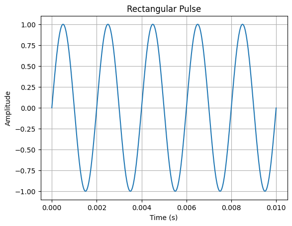

```python
# Pulse shaping block
def generate_sinusoidal_pulse(frequency, duration, sampling_rate):
    # Generate the time axis
    t = np.linspace(0, duration, int(duration * sampling_rate), endpoint=False)

    # Generate the sinusoidal pulse
    pulse = np.sin(2 * np.pi * frequency * t)

    return pulse
sin_freq = 500
pulse = generate_sinusoidal_pulse(sin_freq, pulse_width, sampling_frequency)

# Plotting the pulse
time = np.arange(0, pulse_width, 1 / sampling_frequency)
plt.plot(time, pulse)
plt.xlabel('Time (s)')
plt.ylabel('Amplitude')
plt.title('Rectangular Pulse')
plt.grid(True)
plt.show()
```

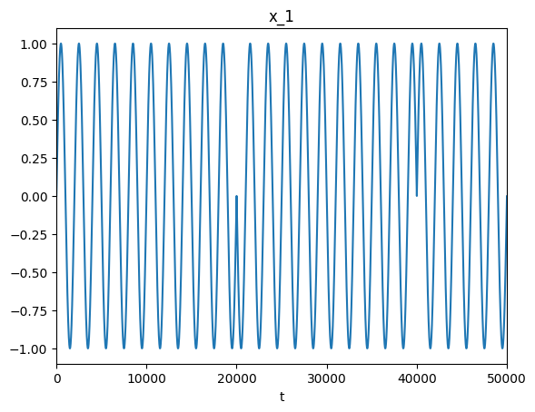

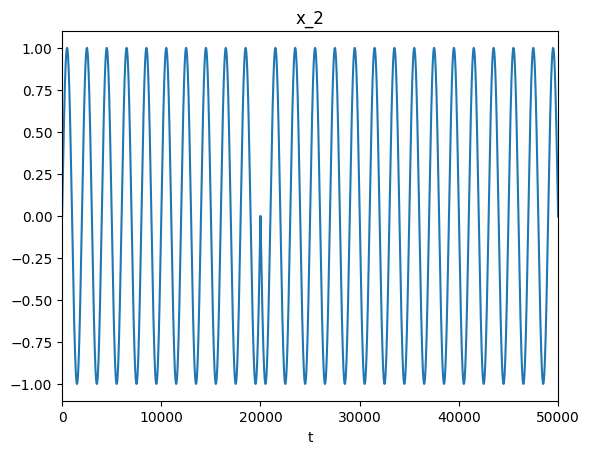

```python
x_1 = PulseShaping(b_1, -1*pulse, pulse)
x_2 = PulseShaping(b_2, -1*pulse, pulse)
plt.plot(x_1)
plt.title("x_1")
plt.xlim(0, 5e4)
plt.xlabel("t")
plt.show()
plt.plot(x_2)
plt.title("x_2")
plt.xlim(0, 5e4)
plt.xlabel("t")
plt.show()
```

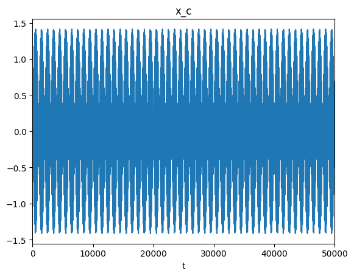

```python
# modulation Block
x_c = AnalogMod(x_1, x_2, sampling_frequency, carrier_frequency)
plt.plot(x_c)
plt.title("x_c")
plt.xlim(0, 5e4)
plt.xlabel("t")
plt.show()
```

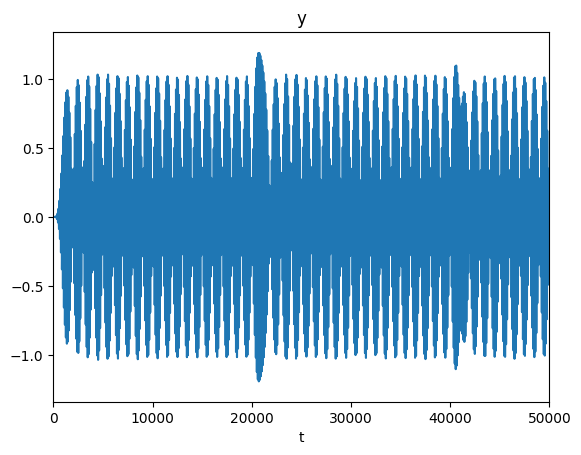

```python
plt.show()
# Receiver
# Channel Block
y = Channel(x_c, sampling_frequency, center_frequency, channel_bandwidth)
plt.plot(y)
plt.title("y")
plt.xlim(0, 5e4)
plt.xlabel("t")
plt.show()
```

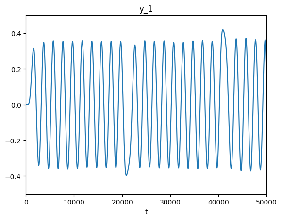

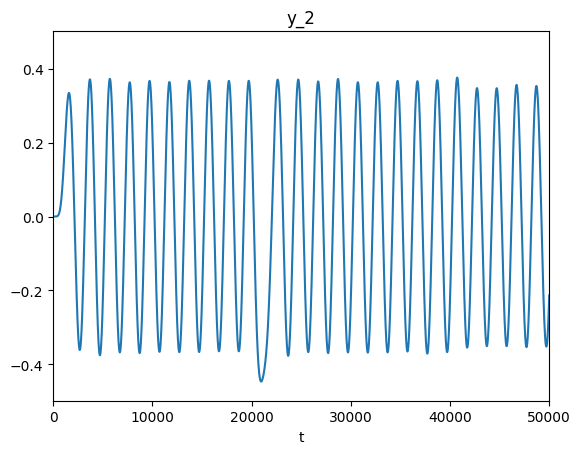

```python
# Demodulation block
y_1, y_2 = AnalogDemod(y, sampling_frequency, signal_bandwidth, carrier_frequency)
plt.plot(y_1)
plt.title("y_1")
plt.xlabel("t")
plt.xlim(0, 5e4)
plt.show()
plt.plot(y_2)
plt.title("y_2")
plt.xlim(0, 5e4)
plt.xlabel("t")
plt.show()
```